# Problem Set 2

Shiyu Sun, Krasimira Kirilova, Marcel Harald Wachter

03.05.2022

## Exercise 1

### a) Simulate the data using the following values: $n = 1000$, $x_{0i} = 1 \ \forall i$, $x_{1i} \sim \mathcal{U}(18,60)$, $x_{2i} \sim \mathcal{B}(0.5)$, $\beta_0 = -2$, $\beta_1 = 0.1$, $\beta_2 = 1$

Load Packages

```r
library(maxLik)
library(latex2exp)
```

Set Seed

```r
set.seed(123)
```

Generate Variables

```r
n <- 1000

x0 <- rep(1, n)
x1 <- runif(n, min = 18, max = 60)
x2 <- rbinom(n, size = 1, prob = 0.5)
x <- cbind(x0, x1, x2)

beta0 <- -2
beta1 <- 0.1
beta2 <- 1
beta <- c(beta0, beta1, beta2)
```

Create Data

```r
pi_x <- (exp(x0 * beta0 + x1 * beta1 + x2 * beta2) / (1 + exp(x0 * beta0 + x1 * beta1 + x2 * beta2)))
y <- rbinom(n, size = 1, prob = pi_x)
data <- cbind(y, x, pi_x)
dataframe <- data.frame(y = y, x0 = x0, x1 = x1, x2 = x2, pi_x = pi_x)
head(data)
```

```
##      y x0       x1 x2      pi_x
## [1,] 1  1 30.07826  0 0.7325944
## [2,] 1  1 51.10882  1 0.9838711
## [3,] 1  1 35.17703  0 0.8202000
## [4,] 1  1 55.08673  1 0.9891069
## [5,] 1  1 57.49963  1 0.9914222
## [6,] 1  1 19.91337  0 0.4978343
```

### b) Write down the likelihood function and the log-likelihood function in R as defined in the lecture.

```r
like <- prod((exp(x0 * beta0 + x1 * beta1 + x2 * beta2) / (1 + exp(x0 * beta0 + x1 * beta1 + x2 * beta2)))^y * (1 - (exp(x0 * beta0 + x1 * beta1 + x2 * beta2) / (1 + exp(x0 * beta0 + x1 * beta1 + x2 * beta2))))^(1 - y))

loglike <- sum(-y * log(1 + exp(-(x0 * beta0 + x1 * beta1 + x2 * beta2))) - (1 - y) * log(1 + exp(x0 * beta0 + x1 * beta1 + x2 * beta2)))
```

### c) Plot the likelihood function and the log-likelihood function for a range of values for the two parameters separately and show that they are maximized at the same value.

For $\beta_0$

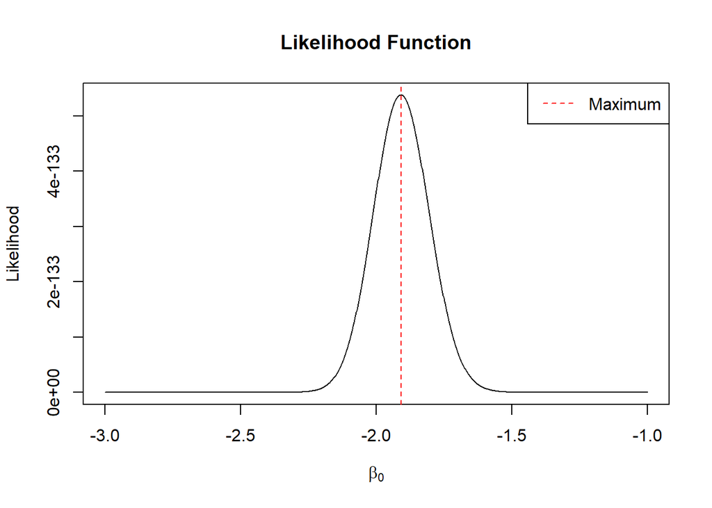

```r
like <- function(beta0) {
  prod((exp(x0 * beta0 + x1 * beta1 + x2 * beta2) / (1 + exp(x0 * beta0 + x1 * beta1 + x2 * beta2)))^y * (1 - (exp(x0 * beta0 + x1 * beta1 + x2 * beta2) / (1 + exp(x0 * beta0 + x1 * beta1 + x2 * beta2))))^(1 - y))
}
l <- Vectorize(like)

loglike <- function(beta0) {
  sum(-y * log(1 + exp(-(x0 * beta0 + x1 * beta1 + x2 * beta2))) - (1 - y) * log(1 + exp(x0 * beta0 + x1 * beta1 + x2 * beta2)))
}
ll <- Vectorize(loglike)

l_curve <- curve(expr = l, from = -3, to = -1, n = 1000, xname = "beta0",
                 xlab = TeX(r"($\beta_0$)"), ylab = "Likelihood",
                 main = "Likelihood Function")
l_max <- l_curve$x[which(l_curve$y==(max(l_curve$y)))]
abline(v = l_max, col = "red", lty = 2)
legend(x = "topright", legend = "Maximum", col = "red", lty = 2)
```

```r
l_max
```

```
## [1] -1.908909
```

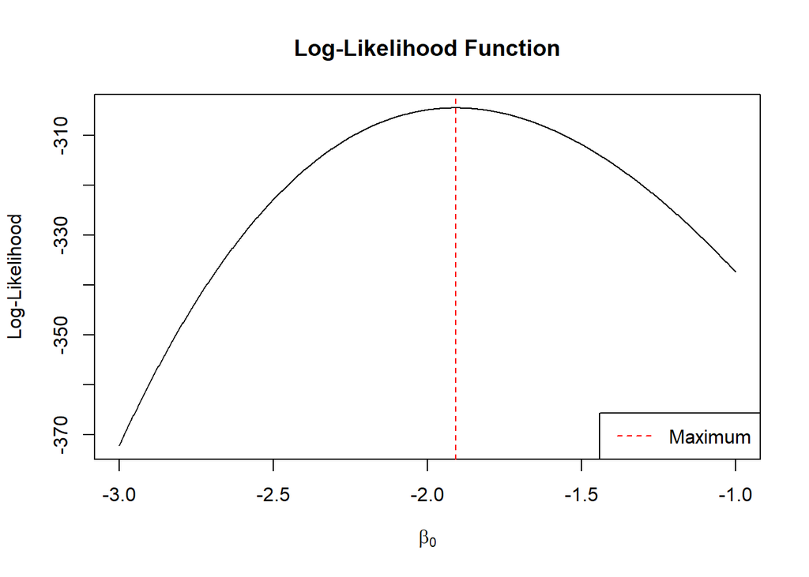

```r
ll_curve <- curve(expr = ll, from = -3, to = -1, n = 1000, xname = "beta0",
                  xlab = TeX(r"($\beta_0$)"), ylab = "Log-Likelihood",
                  main = "Log-Likelihood Function")
ll_max <- ll_curve$x[which(ll_curve$y==(max(ll_curve$y)))]
abline(v = ll_max, col = "red", lty = 2)
legend(x = "bottomright", legend = "Maximum", col = "red", lty = 2)
```

```r
ll_max
```

```
## [1] -1.908909
```

For $\beta_1$

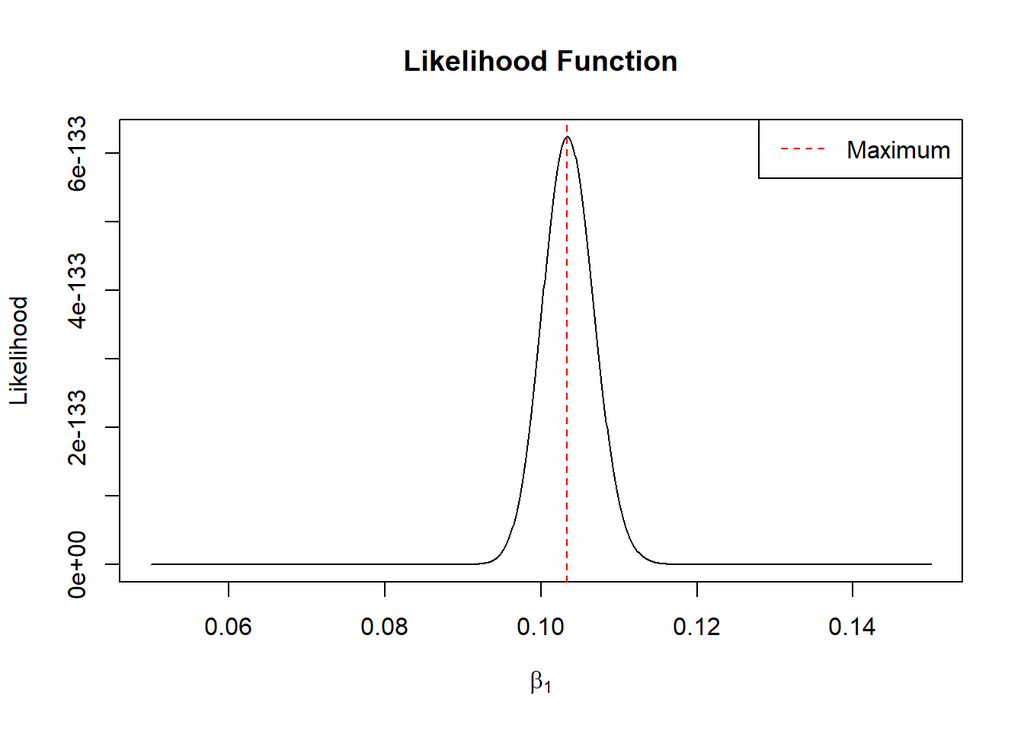

```r
like <- function(beta1) {
  prod((exp(x0 * beta0 + x1 * beta1 + x2 * beta2) / (1 + exp(x0 * beta0 + x1 * beta1 + x2 * beta2)))^y * (1 - (exp(x0 * beta0 + x1 * beta1 + x2 * beta2) / (1 + exp(x0 * beta0 + x1 * beta1 + x2 * beta2))))^(1 - y))
}
l <- Vectorize(like)

loglike <- function(beta1) {
  sum(-y * log(1 + exp(-(x0 * beta0 + x1 * beta1 + x2 * beta2))) - (1 - y) * log(1 + exp(x0 * beta0 + x1 * beta1 + x2 * beta2)))
}
ll <- Vectorize(loglike)

l_curve <- curve(expr = l, from = 0.05, to = 0.15, n = 1000, xname = "beta1",
                 xlab = TeX(r"($\beta_1$)"), ylab = "Likelihood",
                 main = "Likelihood Function")
l_max <- l_curve$x[which(l_curve$y==(max(l_curve$y)))]
abline(v = l_max, col = "red", lty = 2)
legend(x = "topright", legend = "Maximum", col = "red", lty = 2)
```

```r
l_max
```

```
## [1] 0.1033534
```

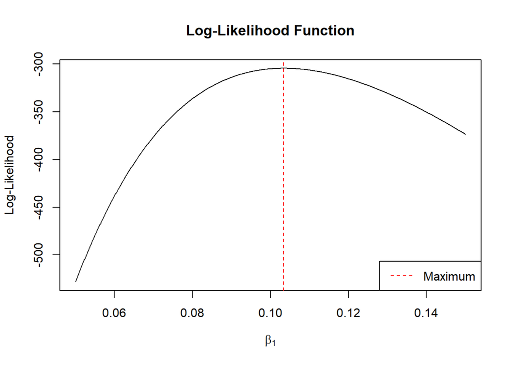

```r
ll_curve <- curve(expr = ll, from = 0.05, to = 0.15, n = 1000, xname = "beta1",
                  xlab = TeX(r"($\beta_1$)"), ylab = "Log-Likelihood",
                  main = "Log-Likelihood Function")
ll_max <- ll_curve$x[which(ll_curve$y==(max(ll_curve$y)))]
abline(v = ll_max, col = "red", lty = 2)
legend(x = "bottomright", legend = "Maximum", col = "red", lty = 2)
```

```r
ll_max
```

```
## [1] 0.1033534
```

For $\beta_2$

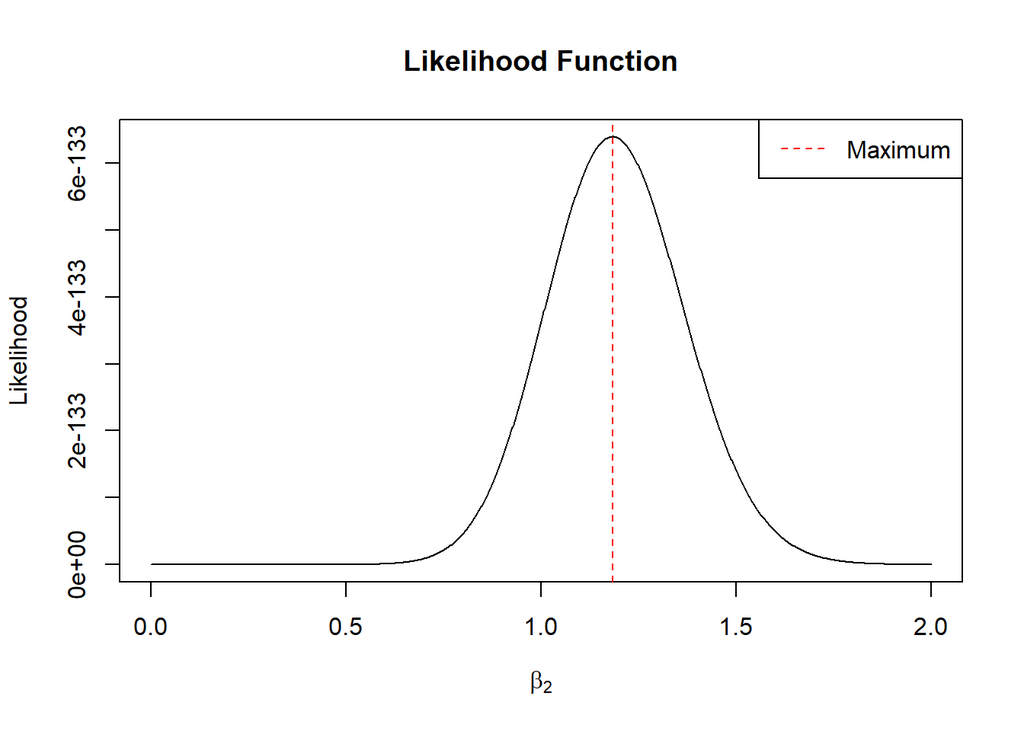

```r
like <- function(beta2) {
  prod((exp(x0 * beta0 + x1 * beta1 + x2 * beta2) / (1 + exp(x0 * beta0 + x1 * beta1 + x2 * beta2)))^y * (1 - (exp(x0 * beta0 + x1 * beta1 + x2 * beta2) / (1 + exp(x0 * beta0 + x1 * beta1 + x2 * beta2))))^(1 - y))
}
l <- Vectorize(like)

loglike <- function(beta2) {
  sum(-y * log(1 + exp(-(x0 * beta0 + x1 * beta1 + x2 * beta2))) - (1 - y) * log(1 + exp(x0 * beta0 + x1 * beta1 + x2 * beta2)))
}
ll <- Vectorize(loglike)

l_curve <- curve(expr = l, from = 0, to = 2, n = 1000, xname = "beta2",
                 xlab = TeX(r"($\beta_2$)"), ylab = "Likelihood",
                 main = "Likelihood Function")
l_max <- l_curve$x[which(l_curve$y==(max(l_curve$y)))]
abline(v = l_max, col = "red", lty = 2)
legend(x = "topright", legend = "Maximum", col = "red", lty = 2)
```

```r
l_max
```

```
## [1] 1.183183
```

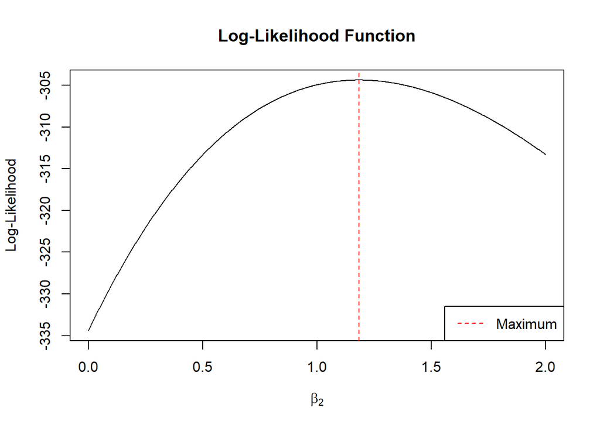

```r
ll_curve <- curve(expr = ll, from = 0, to = 2, n = 1000, xname = "beta2",
                  xlab = TeX(r"($\beta_2$)"), ylab = "Log-Likelihood",
                  main = "Log-Likelihood Function")
ll_max <- ll_curve$x[which(ll_curve$y==(max(ll_curve$y)))]
abline(v = ll_max, col = "red", lty = 2)
legend(x = "bottomright", legend = "Maximum", col = "red", lty = 2)
```

```r
ll_max
```

```
## [1] 1.183183
```

### d) Estimate $\beta_0$, $\beta_1$, $\beta_2$ via maximum likelihood and calculate the standard errors. Use the estimation template provided in the lecture.

```r
loglike <- function(beta) {
  ll <- sum(-y * log(1 + exp(-(x %*% beta))) - (1 - y) * log(1 + exp(x %*% beta)))
}
estim <- maxBFGS(loglike, finalHessian = TRUE, start = c(0, 1, 1))
estim_par <- estim$estimate
estim_par
```

```
## [1] -2.2185137  0.1083019  1.1646161
```

```r
estim_hess <- estim$hessian
cov <- -(solve(estim_hess))
sde <- sqrt(diag(cov))
sde
```

```
## [1] 0.37167489 0.01128377 0.22081351
```

```r
logit <- glm(formula = y ~ x0 + x1 + x2 - 1, family = "binomial", data = dataframe)
summary(logit)
```

```
##
## Call:
## glm(formula = y ~ x0 + x1 + x2 - 1, family = "binomial", data = dataframe)
##
## Deviance Residuals:
##     Min       1Q   Median       3Q      Max
## -2.9329   0.1681   0.3020   0.5231   1.2858
##
## Coefficients:
##    Estimate Std. Error z value Pr(>|z|)
## x0  -2.2185     0.3720  -5.964 2.47e-09 ***
## x1   0.1083     0.0113   9.588  < 2e-16 ***
## x2   1.1646     0.2205   5.281 1.28e-07 ***
## ---
## Signif. codes:  0 '***' 0.001 '**' 0.01 '*' 0.05 '.' 0.1 ' ' 1
##
## (Dispersion parameter for binomial family taken to be 1)
##
##     Null deviance: 1386.29  on 1000  degrees of freedom
## Residual deviance:  608.12  on  997  degrees of freedom
## AIC: 614.12
##
## Number of Fisher Scoring iterations: 6
```

### e) Propose and calculate a suitable method for the interpretation of the coefficients as discussed in the lecture.

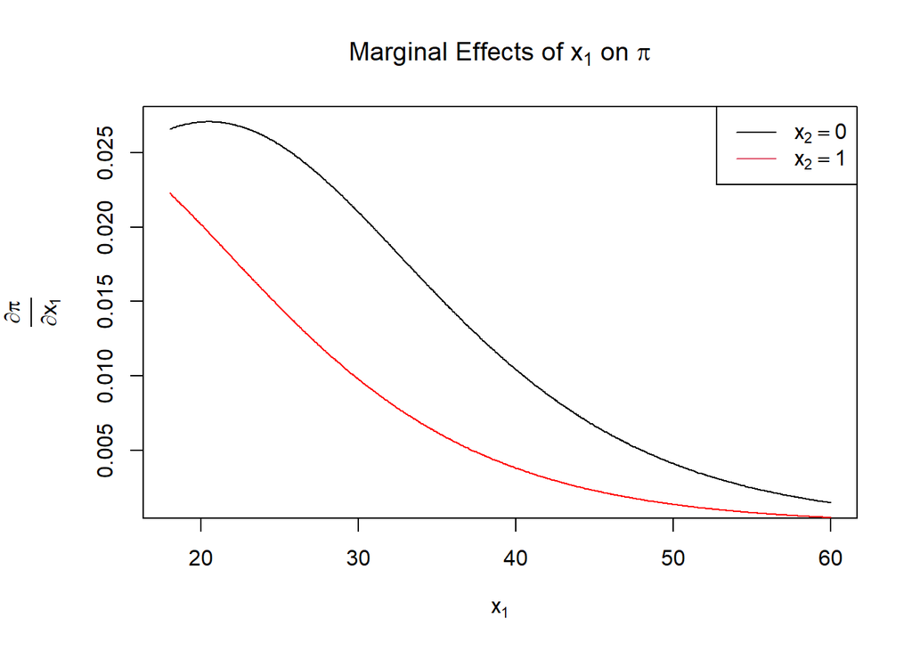

```r
x1 <- sort(runif(n, min = 18, max = 60))
x2 <- 0
dx1 <- c()

for (i in 1:n) {
  pi <- exp(estim_par[1] + estim_par[2] * x1[i] + estim_par[3] * x2) / (1 + exp(estim_par[1] + estim_par[2] * x1[i] + estim_par[3] * x2))
  dx1[i] <- estim_par[2] * (pi) * (1 - pi)
}
par(mar = c(5.1, 5.5, 4.1, 2.1))
plot(x = x1, y = dx1, type = "l", xlab = TeX(r"($x_1$)"),
     ylab = TeX(r"($\frac{\partial \pi}{\partial x_1}$)"),
     main = TeX(r"(Marginal Effects of $x_1$ on $\pi$)"))

x2 <- 1
for (i in 1:n) {
  pi <- exp(estim_par[1] + estim_par[2] * x1[i] + estim_par[3] * x2) / (1 + exp(estim_par[1] + estim_par[2] * x1[i] + estim_par[3] * x2))
  dx1[i] <- estim_par[2] * (pi) * (1 - pi)
}
lines(x = x1, y = dx1, col = "red")
legend(x = "topright", legend = TeX(c(r"($x_2 = 0$)", r"($x_2 = 1$)")),
       lty = c(1, 1), col = c(1, 2))
```

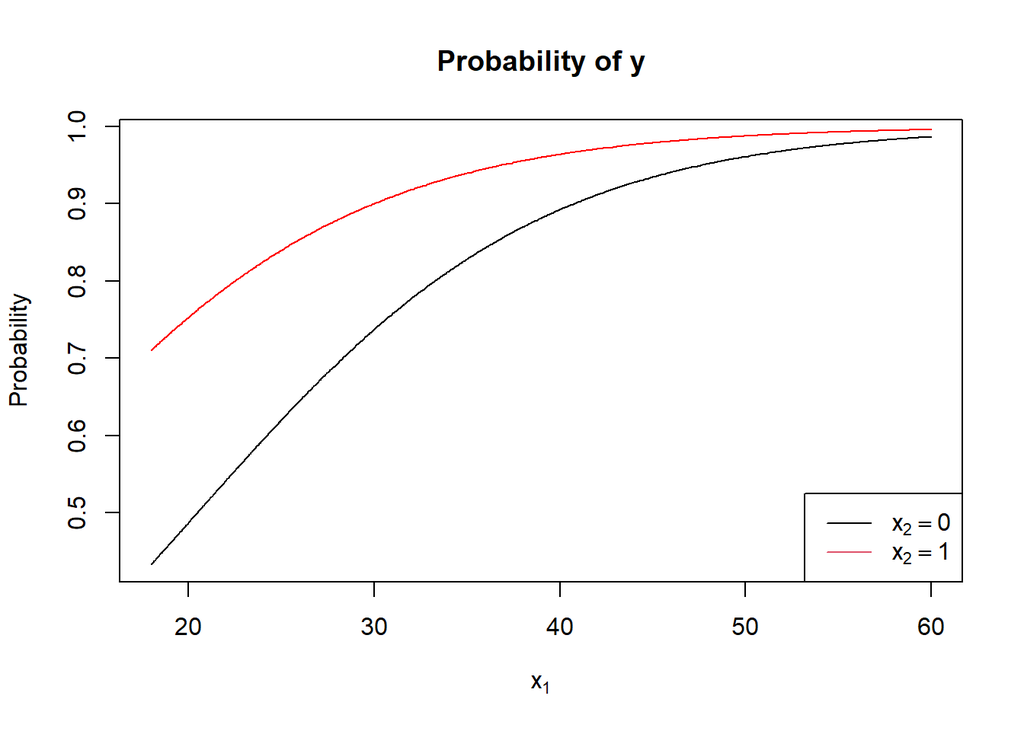

```r
x2 <- 0
pi <- c()
for (i in 1:n) {
  pi[i] <- exp(estim_par[1] + estim_par[2] * x1[i] + estim_par[3] * x2) / (1 + exp(estim_par[1] + estim_par[2] * x1[i] + estim_par[3] * x2))
}
plot(x = x1, y = pi, type = "l", xlab = TeX(r"($x_1$)"), ylab = "Probability",
     main = "Probability of y")

x2 <- 1
for (i in 1:n) {
  pi[i] <- exp(estim_par[1] + estim_par[2] * x1[i] + estim_par[3] * x2) / (1 + exp(estim_par[1] + estim_par[2] * x1[i] + estim_par[3] * x2))
}
lines(x = x1, y = pi, col = "red")
legend(x = "bottomright", legend = TeX(c(r"($x_2 = 0$)", r"($x_2 = 1$)")),
       lty = c(1, 1), col = c(1, 2))
```

### f) Visualize your results, including the associated uncertainty around the estimates.

```r
model <- glm(formula = y ~ x0 + x1 + x2 - 1, family = "binomial", data = dataframe)

x_to_visualize <- sort(x1)

plot_confidence_itervals <- function(x2, xlab) {
  probs <- predict(model, newdata = data.frame(x0 = x0, x1 = x_to_visualize, x2 = x2),
                   type = "response", se.fit = TRUE)

  probs_fit <- probs$fit
  probs_upper <- probs$fit + probs$se.fit * 1.96 # 95% confidence interval
  probs_lower <- probs$fit - probs$se.fit * 1.96 # 95% confidence interval

  plot(x1, y, pch = 16, cex = 1, ylab="Probability", xlab = xlab,
       main = "Probability of y with 95% Confidence Interval")
  grid()
  polygon(c(rev(x_to_visualize), x_to_visualize),
          c(rev(probs_lower), probs_upper), col="grey90", border=NA)

  lines(x_to_visualize, probs_fit, lwd=2)
  lines(x_to_visualize, probs_upper, lwd=2, col="red")
  lines(x_to_visualize, probs_lower, lwd=2, col="red")

  abline(h=0.1, lty=2)
  abline(h=0.5, lty=2)
  abline(h=0.9, lty=2)
}
```

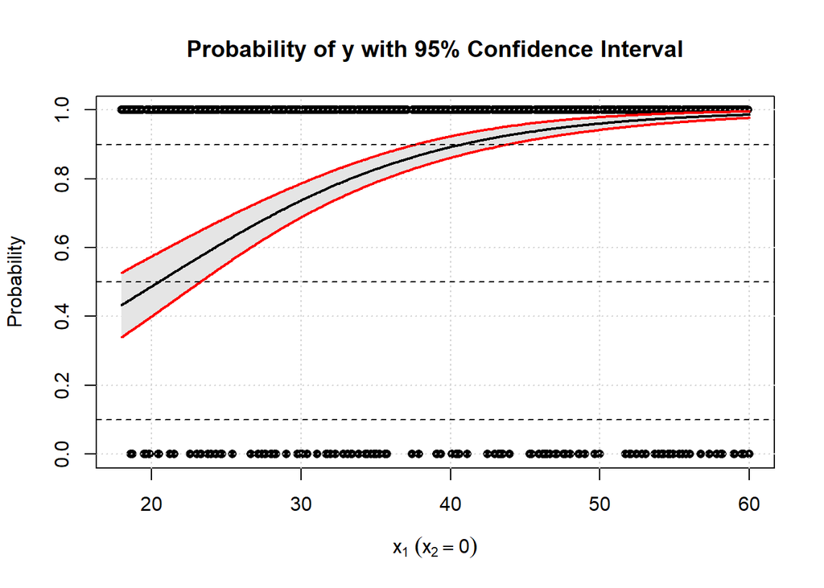

```r
plot_confidence_itervals(x2=0, xlab = TeX(r"($x_1$ $(x_2 = 0)$)"))
```

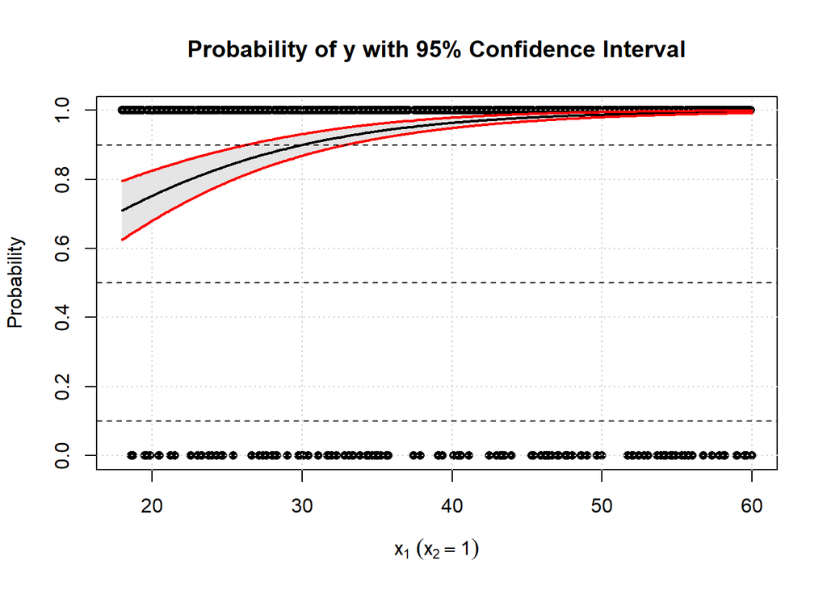

```r
plot_confidence_itervals(x2=1, xlab = TeX(r"($x_1$ $(x_2 = 1)$)"))
```

## Exercise 2

### a) Calculate the average training and the average prediction error for 100 simulation runs.

Set Seed

```r
set.seed(456)
```

Generate Test Variables

```r
n_test <- 1000

x0_test <- rep(1, n_test)
x1_test <- runif(n_test, min = 18, max = 60)
x2_test <- rbinom(n_test, size = 1, prob = 0.5)
x_test <- cbind(x0_test, x1_test, x2_test)
```

Create Test Data

```r
pi_x_test <- (exp(x0_test * beta0 + x1_test * beta1 + x2_test * beta2) / (1 + exp(x0_test * beta0 + x1_test * beta1 + x2_test * beta2)))
y_test <- rbinom(n_test, size = 1, prob = pi_x_test)
data_test <- cbind(y_test, x_test, pi_x_test)
dataframe_test <- data.frame(y = y_test, x0 = x0_test, x1 = x1_test, x2 = x2_test, pi_x_test = pi_x_test)
```

Average Training Error

```r
mse <- 1 / n_test * sum((y_test - pi_x_test)^2)
```

Average Prediction Error

```r
ape <- mean((y_test - pi_x_test)^2)
```

Simulations

```r
set.seed(2198)
ape_cont <- c()
mse_cont <- c()
beta0 <- -2
beta1 <- 0.1
beta2 <- 1
for (i in 1:100) {
  n <- 1000
  x0 <- rep(1, n)
  x1 <- runif(n, min = 18, max = 60)
  x2 <- rbinom(n, size = 1, prob = 0.5)
  x <- cbind(x0, x1, x2)
  pi_x <- (exp(x0 * beta0 + x1 * beta1 + x2 * beta2) / (1 + exp(x0 * beta0 + x1 * beta1 + x2 * beta2)))
  y <- rbinom(n, size = 1, prob = pi_x)

  model <- glm(formula = y ~ x0 + x1 + x2 - 1, family = "binomial")
  beta0_train <- model$coefficients[1]
  beta1_train <- model$coefficients[2]
  beta2_train <- model$coefficients[3]

  pi_x_train <- (exp(x0 * beta0_train + x1 * beta1_train + x2 * beta2_train) / (1 + exp(x0 * beta0_train + x1 * beta1_train + x2 * beta2_train)))
  y_train <- rbinom(n = n, size = 1, prob = pi_x_train)

  n_test <- 1000
  x0_test <- rep(1, n_test)
  x1_test <- runif(n_test, min = 18, max = 60)
  x2_test <- rbinom(n_test, size = 1, prob = 0.5)
  x_test <- cbind(x0_test, x1_test, x2_test)

   pi_x_test <- (exp(x0_test * beta0 + x1_test * beta1 + x2_test * beta2) / (1 + exp(x0_test * beta0 + x1_test * beta1 + x2_test * beta2)))
  y_test <- rbinom(n_test, size = 1, prob = pi_x_test)

  pi_x_test_pred <- (exp(x0_test * beta0_train + x1_test * beta1_train + x2_test * beta2_train) / (1 + exp(x0_test * beta0_train + x1_test * beta1_train + x2_test * beta2_train)))
  y_test_pred <- rbinom(n_test, size = 1, prob = pi_x_test_pred)

  mse_cont[i] <- 1 / n * sum(!(y == y_train))
  ape_cont[i] <- 1 / n_test * sum(!(y_test == y_test_pred))
}
```

Plot Errors

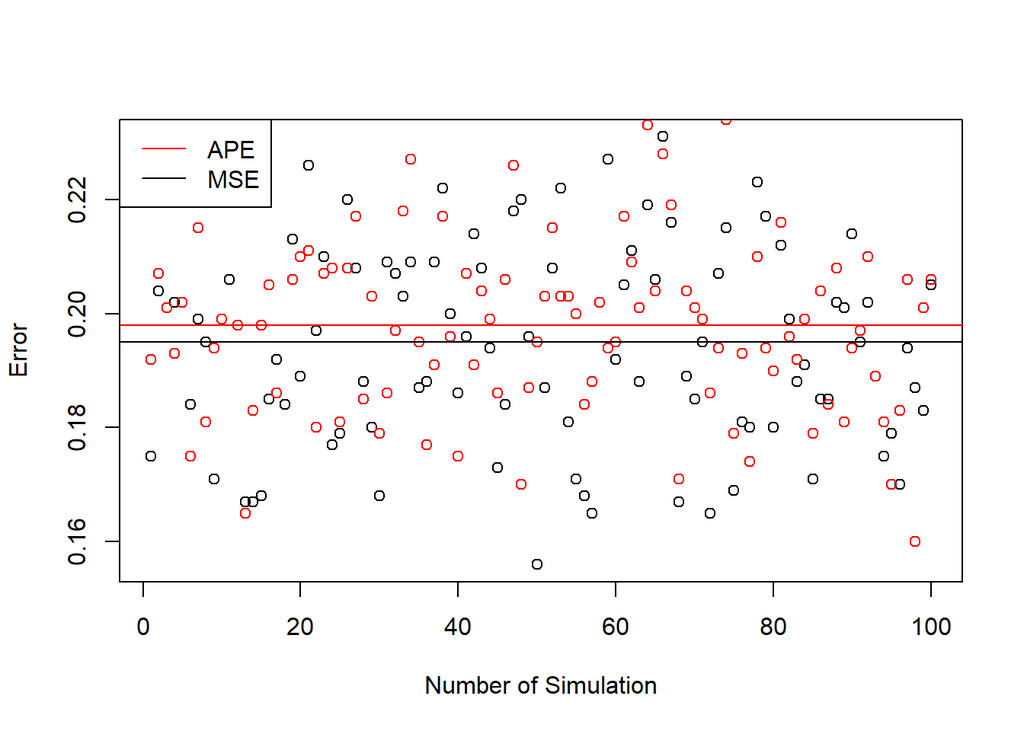

```r
plot(mse_cont, xlab = "Number of Simulation", ylab = "Error")
points(ape_cont, col = "red")
abline(h = mean(mse_cont))
abline(h = mean(ape_cont), col = "red")
legend(x = "topleft", legend = c("APE", "MSE"), lty = c(1, 1), col = c("red", "black"))
```

### b) Consider the way the data is generated: propose and implement a change in the data generating process that (by your conjecture) will lead to an increase in the test error rate, but a decrease in the training error rate.

```r
set.seed(2198)
ape_cont <- c()
mse_cont <- c()
beta0 <- -2
beta1 <- 0.1
beta2 <- 1
for (i in 1:100) {
  n <- 100
  x0 <- rep(1, n)
  x1 <- runif(n, min = 18, max = 60)
  x2 <- rbinom(n, size = 1, prob = 0.5)
  x <- cbind(x0, x1, x2)
  pi_x <- (exp(x0 * beta0 + x1 * beta1 + x2 * beta2) / (1 + exp(x0 * beta0 + x1 * beta1 + x2 * beta2)))
  y <- rbinom(n, size = 1, prob = pi_x)

  model <- glm(formula = y ~ x0 + x1 + x2 - 1, family = "binomial")
  beta0_train <- model$coefficients[1]
  beta1_train <- model$coefficients[2]
  beta2_train <- model$coefficients[3]

  pi_x_train <- (exp(x0 * beta0_train + x1 * beta1_train + x2 * beta2_train) / (1 + exp(x0 * beta0_train + x1 * beta1_train + x2 * beta2_train)))
  y_train <- rbinom(n = n, size = 1, prob = pi_x_train)

  n_test <- 1000
  x0_test <- rep(1, n_test)
  x1_test <- runif(n_test, min = 18, max = 60)
  x2_test <- rbinom(n_test, size = 1, prob = 0.2)
  x_test <- cbind(x0_test, x1_test, x2_test)

   pi_x_test <- (exp(x0_test * beta0 + x1_test * beta1 + x2_test * beta2) / (1 + exp(x0_test * beta0 + x1_test * beta1 + x2_test * beta2)))
  y_test <- rbinom(n_test, size = 1, prob = pi_x_test)

  pi_x_test_pred <- (exp(x0_test * beta0_train + x1_test * beta1_train + x2_test * beta2_train) / (1 + exp(x0_test * beta0_train + x1_test * beta1_train + x2_test * beta2_train)))
  y_test_pred <- rbinom(n_test, size = 1, prob = pi_x_test_pred)

  mse_cont[i] <- 1 / n * sum(!(y == y_train))
  ape_cont[i] <- 1 / n_test * sum(!(y_test == y_test_pred))
}
```

Plot Errors

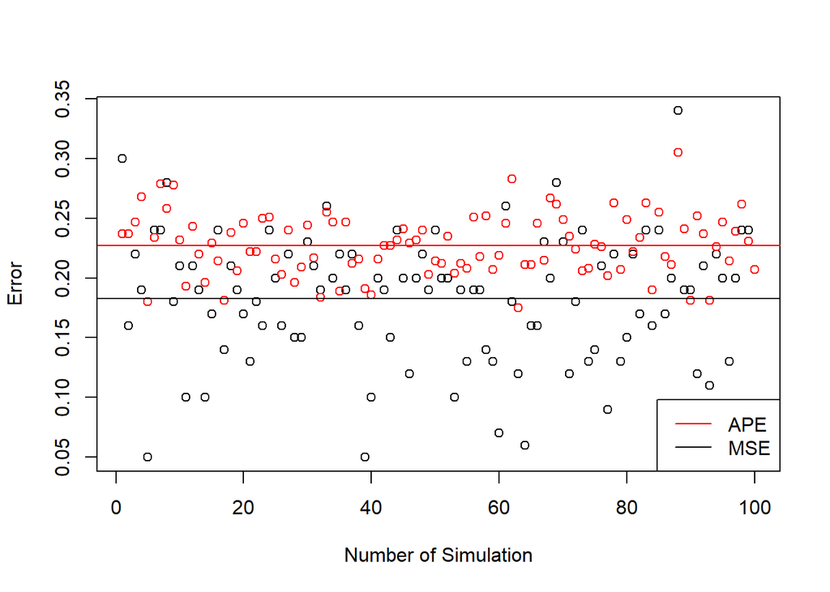

```r
plot(mse_cont, xlab = "Number of Simulation", ylab = "Error")
points(ape_cont, col = "red")
abline(h = mean(mse_cont))
abline(h = mean(ape_cont), col = "red")
legend(x = "bottomright", legend = c("APE", "MSE"), lty = c(1, 1), col = c("red", "black"))
```

### c) Bonus: Consider your assignment in 1 c): propose changes in the data generating process above that would make the likelihood function less informative over the range of parameter values. Implement these changes and show your results graphically.